# Bad Plot vs. Good Plot

Nicole Ayala

2023-03-30

### **Purpose of this Assignment**

- To assess my coding ability ad knowledge of what makes a good plot versus a bad plot.

#### ~ Requirements ~

- All plots must be made in ggplot2, with code visible in the Rmarkdown document.
- The data must be visible.
- The good plot and the bad plot should be based on the same, or similar, data.
- Will be posted on Twitter
- Clearly articulate each principle of data visualization that is broken or not

## BAD PLOT

```r
### Load the libraries ###
library(tidyverse)
library(here)
```

```r
library(ggplot2)
library(magick)
library(devtools)
library(showtext)
library(beyonce)
library(extrafont)
library(dplyr)
library(extrafont)

### Load in the Data ###
cancer<-read.csv(here("GoodPlotBadPlot","Data", "breastcancer_UMC.csv")) # loading data
glimpse(cancer)
```

```
## Rows: 272
## Columns: 10
## $ age          <chr> "40-49", "50-59", "50-59", "40-49", "40-49", "50-59", "50…
## $ mefalsepause <chr> "premefalse", "ge40", "ge40", "premefalse", "premefalse",…
## $ tumor.size   <chr> "15-19", "15-19", "35-39", "35-39", "30-34", "25-29", "40…
## $ inv.falsedes <chr> "0-2", "0-2", "0-2", "0-2", "3-5", "3-5", "0-2", "0-2", "…
## $ falsede.caps <chr> "true", "false", "false", "true", "true", "false", "false…
## $ deg.malig    <int> 3, 1, 2, 3, 2, 2, 3, 2, 2, 2, 2, 2, 1, 2, 2, 3, 1, 2, 3, …
## $ breast       <chr> "right", "right", "left", "right", "left", "right", "left…
## $ breast.quad  <chr> "left_up", "central", "left_low", "left_low", "right_up",…
## $ irradiat     <chr> "false", "false", "false", "true", "false", "true", "fals…
## $ class        <chr> "recurrence-events", "false-recurrence-events", "recurren…
```

```r
# View(cancer)

loadfonts()
```

[output not shown]

[output cut: 545 more lines]

[output not shown]

```r
# want to output to .ps files instead of .pdf, use:
# loadfonts(device="postscript")
```

```r
#font_import(paths = "C:/Users/nikky/AppData/Local/Microsoft/Windows/Fonts")
# Register fonts for Windows bitmap output
font_add(family = "Algerian", regular ="alger.ttf")
showtext_auto()
shrek<-image_read("https://www.pngplay.com/wp-content/uploads/14/Shrek-Family-Transparent-Free-PNG.png")

donkey<-image_read("https://www.pngplay.com/wp-content/uploads/12/Donkey-From-Shrek-Download-Free-PNG.png")
#donkey
#shrek

cancer <- cancer %>%
mutate(class = fct_recode(class, "onions have layers" = "false-recurrence-events")) %>%
  mutate(class = fct_recode(class, "do you know the muffin man" = "recurrence-events"))
```

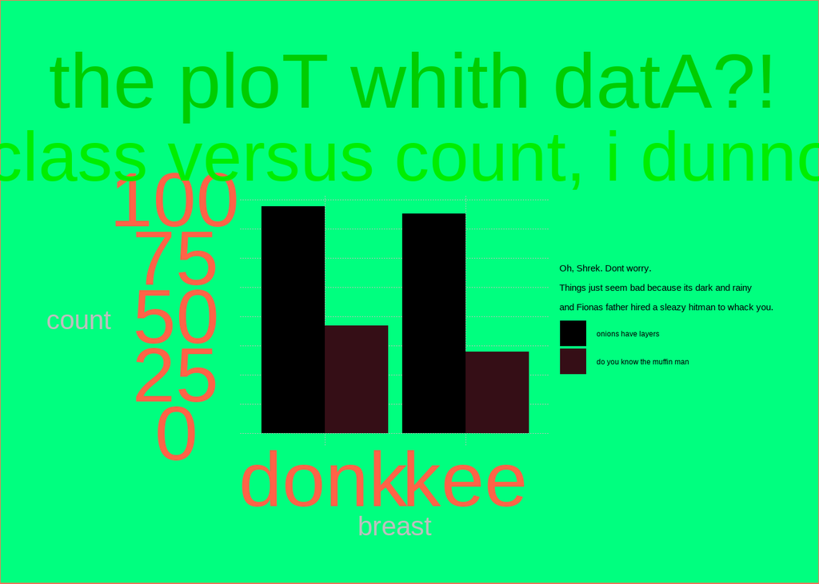

```r
ggplot(data = cancer,
       aes(x=breast,
           fill=class)) +
  geom_bar(position='dodge')+
  theme(text = element_text(family = "Algeria")) +
  labs(title='the ploT whith datA?!',
       subtitle ="class versus count, i dunno",
       x='breast',
       y='count',
       fill = 'Oh, Shrek. Dont worry.\nThings just seem bad because its dark and rainy\nand Fionas father hired a sleazy hitman to whack you.') +

  theme_void() +
  scale_x_discrete(labels = c("donk", "kee")) +
   scale_fill_manual(values = beyonce_palette(8)) +
  theme(plot.title = element_text(size = 95, hjust = 0.5, color ="green3"),
        plot.title.position = "plot", # title adjustments
        plot.subtitle = element_text(size =86,hjust = 0.5, lineheight = 1.1, color = "green2"),
        axis.title = element_text(size=33,color = "grey", hjust = 0.5), # title adjustments
        axis.text = element_text(size = 95,color = "tomato1",hjust = 0.5), # text adjustments
        panel.grid = element_line(linewidth = 0.35, linetype = "dotted", color = "grey"), # background gridlines
        plot.margin = unit(c(1.0, 1.0, 1.0, 1.0), "cm"), # margin adjustments
        plot.background = element_rect(color = "coral1", fill="springgreen1"))
```

[figure not shown]

```r
# read in the plot as a magick image and make a composite plot
shrekplot<-image_read(here("GoodPlotBadPlot","Output","BadPlotFinal.png"))
shrekout <- image_composite(shrekplot, shrek, offset = "+30+70")
donkout <- image_composite(shrekout, donkey, offset = "+800+200")
donkout
```

### Reasons as to why this was a *bad plot*

For starters, there is no clean cut story the data entails. The data was never filtered out so the data itself is not very tidy. But getting to the more aesthetic appeal of this plot, it’s not a positive eye catcher but it will turn heads. On a positive note there is a title, subtitle and axes. However, they are at the worst text size and colors. I apologize in advance to anyone who is red/green colorblind, this is severely difficult to read and interpret. The title and subtitles give no actual meaningful summary, suggestion or overview about what this plot is even about. The background is an unpleasant neon green that is not extremely appealing or pleasing to the eye as well as similar in color to the title and subtitles. There are images in inappropriate places and do not correlate to the breast cancer data set I was using.The visualizations of the y axis scale in particular is too big in my opinion which can make it misleading when attempting to interpret in which breast is cancer most commonly found in individuals from 20-70 year olds.It has poor grid lines making it even more unappealing. It has a legend that does not correlate to the actual data that was used. The bar plot colors were based off of the beyonce palette, so it was a step up from just keeping it to the original base R colors. However, the size of the plot is tiny meaning it is difficult to read and not clear about what this plot is depicting. It poorly communicates data in an irresponsible manner. All in all, I do not think this plot looks awesome in the slightest way. This would definitely not follow reproducible protocol.

## GOOD PLOT

```r
### Load the libraries ###

library(tidyverse)
library(here)
library(ggplot2)
library(hrbrthemes)
library(janitor)
library(devtools)
library(dplyr)
library(showtext)
library(extrafont)
library(gridExtra)
### Load in the Data ###
cancer <- read.csv(here("GoodPlotBadPlot","Data", "breastcancer_UMC.csv"))
glimpse(cancer) # look at data
```

```
## Rows: 272
## Columns: 10
## $ age          <chr> "40-49", "50-59", "50-59", "40-49", "40-49", "50-59", "50…
## $ mefalsepause <chr> "premefalse", "ge40", "ge40", "premefalse", "premefalse",…
## $ tumor.size   <chr> "15-19", "15-19", "35-39", "35-39", "30-34", "25-29", "40…
## $ inv.falsedes <chr> "0-2", "0-2", "0-2", "0-2", "3-5", "3-5", "0-2", "0-2", "…
## $ falsede.caps <chr> "true", "false", "false", "true", "true", "false", "false…
## $ deg.malig    <int> 3, 1, 2, 3, 2, 2, 3, 2, 2, 2, 2, 2, 1, 2, 2, 3, 1, 2, 3, …
## $ breast       <chr> "right", "right", "left", "right", "left", "right", "left…
## $ breast.quad  <chr> "left_up", "central", "left_low", "left_low", "right_up",…
## $ irradiat     <chr> "false", "false", "false", "true", "false", "true", "fals…
## $ class        <chr> "recurrence-events", "false-recurrence-events", "recurren…
```

```r
#View(cancer)
attach(cancer) # all the data variables
head(cancer) # shows beginning of  dataset
```

```
##     age mefalsepause tumor.size inv.falsedes falsede.caps deg.malig breast
## 1 40-49   premefalse      15-19          0-2         true         3  right
## 2 50-59         ge40      15-19          0-2        false         1  right
## 3 50-59         ge40      35-39          0-2        false         2   left
## 4 40-49   premefalse      35-39          0-2         true         3  right
## 5 40-49   premefalse      30-34          3-5         true         2   left
## 6 50-59   premefalse      25-29          3-5        false         2  right
##   breast.quad irradiat                   class
## 1     left_up    false       recurrence-events
## 2     central    false false-recurrence-events
## 3    left_low    false       recurrence-events
## 4    left_low     true false-recurrence-events
## 5    right_up    false       recurrence-events
## 6     left_up     true false-recurrence-events
```

```r
str(cancer) # shows structure of dataset
```

```
## 'data.frame':    272 obs. of  10 variables:
##  $ age         : chr  "40-49" "50-59" "50-59" "40-49" ...
##  $ mefalsepause: chr  "premefalse" "ge40" "ge40" "premefalse" ...
##  $ tumor.size  : chr  "15-19" "15-19" "35-39" "35-39" ...
##  $ inv.falsedes: chr  "0-2" "0-2" "0-2" "0-2" ...
##  $ falsede.caps: chr  "true" "false" "false" "true" ...
##  $ deg.malig   : int  3 1 2 3 2 2 3 2 2 2 ...
##  $ breast      : chr  "right" "right" "left" "right" ...
##  $ breast.quad : chr  "left_up" "central" "left_low" "left_low" ...
##  $ irradiat    : chr  "false" "false" "false" "true" ...
##  $ class       : chr  "recurrence-events" "false-recurrence-events" "recurrence-events" "false-recurrence-events" ...
```

```r
#summary(cancer) # shows each column and other attributes


# pair up corr. coefficient btwn variables
#pairs.panels(cancer) # menopause and age is stat sig
#df <- data.frame(`tumor-size`=c('0-4', '5-9', '10-14', '15-19', '20-24', '25-29', '30-34', '35-39', '40-44', '45-49', '50-54'))


### Filtering the Data ### Part 1
# cancer = filter(cancer, `breast-quad`!= '?' & node.caps != '?')

### Filter Data ### Part 2
data <- cancer %>%
filter(tumor.size>"35-39")


## Loading Google fonts (https://fonts.google.com/)

#select('tumor_size', age, class, `deg-malig`) %>%
#group_by(class) %>%
#mutate(avg = mean(`tumor-size`, na.rm = TRUE)) %>%
#filter(class == "recurrence-events") %>%
#filter('tumor-size'>"10-14" & age<"60-69")
```

[figure not shown]

```r
# Make the Ridgeline Plot
# Register fonts for Windows bitmap output
font_add(family = "Comic", regular = "comic.ttf")
showtext_auto()
ggplot(data=data,aes(x=`deg.malig`,# degree of malignancy
           group = `tumor.size`,# group by tumor size
           fill = tumor.size)) + #  fill by tumor size
  geom_density(adjust=1.5, alpha=0.5,  show.legend = FALSE) + # adjusting size
 theme(text = element_text(family = "Comic")) +
  theme_ipsum_pub() + # cute rainbow theme
  theme_minimal() +
  labs(x = "Degree of Malignancy", y = "Tumor Size", title = "Correlation of the Degree of Malignancy w/ Tumor Size within Patients that Have Breast Cancer", subtitle = "There are 3 ranges of tumor sizes from 40-54 (cm) depicting the larger the mass size of the tumor, the more risk it will be malignant.") + # title and subtitles + x and y axes
  theme(panel.grid.major = element_blank(),
        panel.grid.minor = element_blank()) +
  scale_color_brewer(palette = "Blues") +
   scale_fill_discrete(breaks=c('40-44','45-49', '50-54')) + # arranged order of legend
  theme(axis.title = element_text(size = 30, color = "mediumorchid4"),
  panel.background = element_rect(fill = "white"))
```

```r
  # background color is white




ggsave(here("GoodPlotBadPlot","Output","GoodPlot.png"), # saved the good plot
        width = 7, height = 8) # adjust size of graph in inches
```